# R Notebook

Juliusz Ciazynski

## The main aim of the script is to visualise a few of the plots regarding the information about exoplanets from NASA official database.

```r
library(dplyr)
library(ggplot2)
library(tidyr)
library(knitr)
library(stringr)
```

Downloading the libraries

```r
exoplanets <- read.csv("PS_2024.06.13_15.36.49.csv")
```

Reading the data from a file

```r
#we can get rid of some useless informations at the start
exoplanets <- exoplanets[-(1:48), ]

#however, column names are of some use for us
column_names <- exoplanets[1:43]

#nicely creating a matrix which is useful
data_matrix <- matrix(exoplanets[-(1:43)], ncol = length(column_names), byrow = TRUE)
df <- as.data.frame(data_matrix, stringsAsFactors = FALSE)
colnames(df) <- column_names
```

The obtained data is in a poor state, it has to be pre-processed before we can continue in any way with that.

```r
df <- df %>% select(-1)
```

one more useless column

## Task 1.

### Plot a bar graph showing the number of confirmed exoplanets for each year

```r
df <- df %>%
  mutate(disc_year = as.integer(str_sub(disc_year, 1, 4)))
```

Firstly, lets obtain the year of the discovery of every exoplanet

```r
df_by_year <- df %>%
  group_by(disc_year) %>%
  summarize(count = n())
```

### And later, with group by we can group all of the exoplanets by their year of discovery

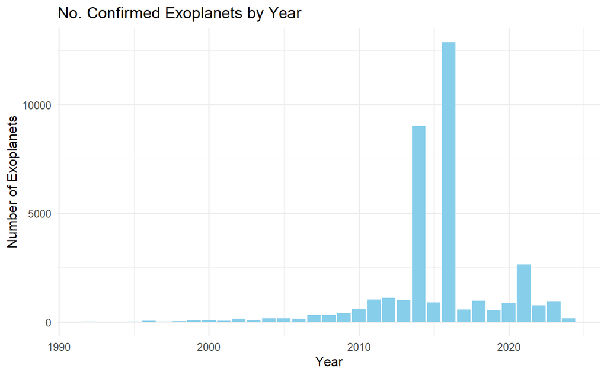

```r
ggplot(df_by_year, aes(x = disc_year, y = count)) +
  geom_bar(stat = "identity", fill = "skyblue") +
  labs(title = "No. Confirmed Exoplanets by Year",
       x = "Year",
       y = "Number of Exoplanets") +
  theme_minimal()
```

Now we can plot what we have done

```r
df_by_year <- df_by_year %>%
  arrange(disc_year) %>%
  mutate(cumulative_count = cumsum(count))
```

### The second part is to plot line graph with a confirmed exoplanet versus time. For it, we need to calculate the cumsum of them.

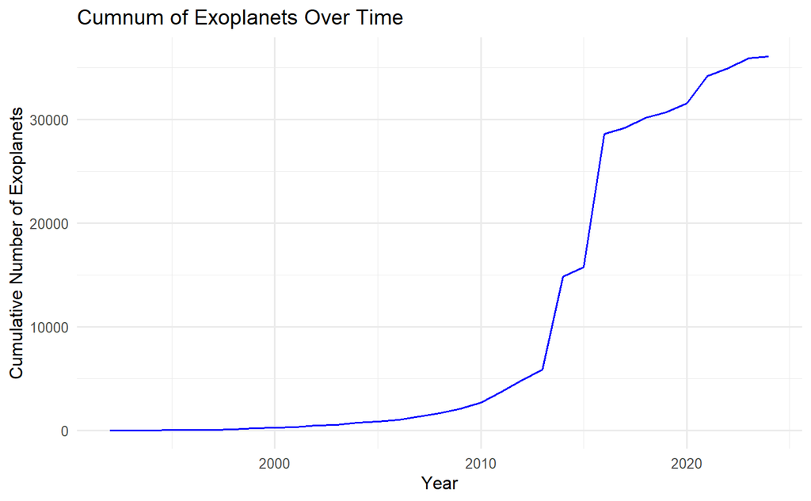

```r
ggplot(df_by_year, aes(x = disc_year, y = cumulative_count)) +
  geom_line(color = "blue") +
  labs(title = "Cumnum of Exoplanets Over Time",
       x = "Year",
       y = "Cumulative Number of Exoplanets") +
  theme_minimal()
```

And the linegraph

## TASK 2

### Create a table containing information about the different methods of observing exoplanets (discoverymethod column) and the percentage of planets discovered by each method.

```r
df_discoverymethods <- df %>%
  group_by(discoverymethod) %>%
  summarize(count = n()) %>%
  mutate(percentage = (count / sum(count)) * 100) %>%
  arrange(desc(percentage))
```

We can create another dataframe with nicely grouped by methods and percentage calculated

```r
kable(df_discoverymethods, format = "markdown", col.names = c("Method", "Count", "Percentage"))
```

| Method | Count | Percentage |
| --- | --- | --- |
| Transit | 32564 | 90.2374816 |
| Radial Velocity | 2523 | 6.9914374 |
| Microlensing | 651 | 1.8039737 |
| Imaging | 147 | 0.4073489 |
| Transit Timing Variations | 138 | 0.3824092 |
| Eclipse Timing Variations | 24 | 0.0665059 |
| Orbital Brightness Modulation | 21 | 0.0581927 |
| Pulsar Timing | 13 | 0.0360241 |
| Astrometry | 3 | 0.0083132 |
| Pulsation Timing Variations | 2 | 0.0055422 |
| Disk Kinematics | 1 | 0.0027711 |

And also, nicely print it

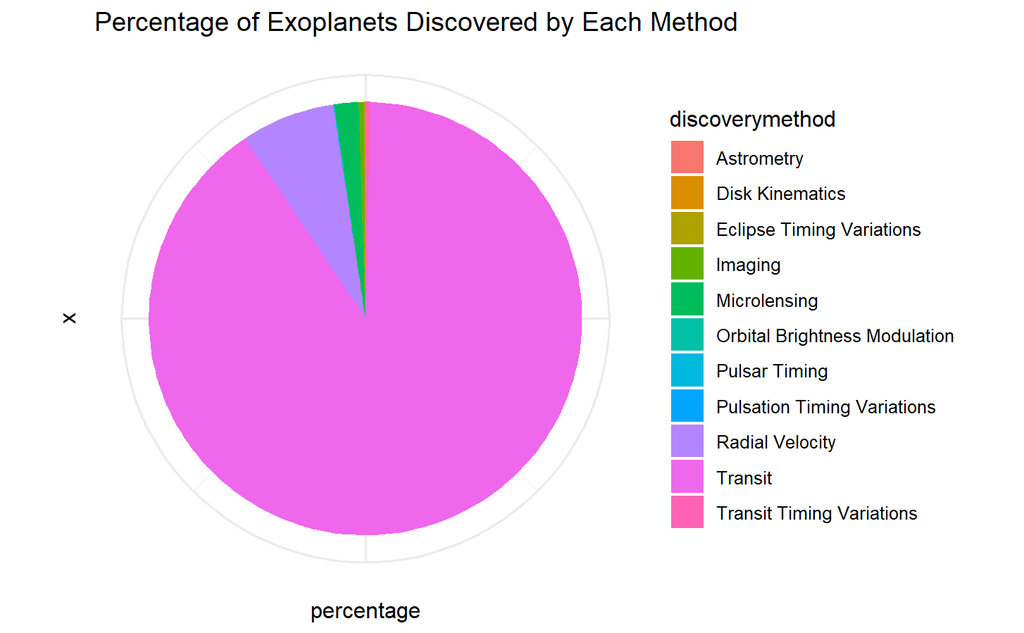

```r
ggplot(df_discoverymethods, aes(x = "", y = percentage, fill = discoverymethod)) +
  geom_bar(width = 1, stat = "identity") +
  coord_polar("y") +
  labs(title = "Percentage of Exoplanets Discovered by Each Method") +
  theme_minimal() +
  theme(axis.text.x = element_blank())
```

And of course, plot it

### Calculating the average size and mass (in comparison to Earth) for each discovery method

```r
df <- df %>%
  mutate(
    discoverymethod = na_if(discoverymethod, ""),
    pl_bmasse = na_if(pl_bmasse, ""),
    pl_rade = na_if(pl_rade, ""),
    pl_bmasse = as.numeric(pl_bmasse),
    pl_rade = as.numeric(pl_rade)
  )
```

Some small preprocessing beforehand NA values and non numerics are not welcomed here

```r
average_params <- df %>%
  group_by(discoverymethod) %>%
  summarize(average_mass = mean(pl_bmasse, na.rm = TRUE),
            average_radius = mean(pl_rade, na.rm = TRUE))
```

Group by, again

```r
kable(average_params, format = "markdown", col.names = c("Method", "Average Mass", "Average Radius"))
```

| Method | Average Mass | Average Radius |
| --- | --- | --- |
| Astrometry | 3788.4014 | NaN |
| Disk Kinematics | 794.5750 | NaN |
| Eclipse Timing Variations | 1890.0569 | NaN |
| Imaging | 4563.0021 | 18.652027 |
| Microlensing | 703.0622 | NaN |
| Orbital Brightness Modulation | 421.6542 | 11.437923 |
| Pulsar Timing | 172.1276 | NaN |
| Pulsation Timing Variations | 2383.7250 | NaN |
| Radial Velocity | 993.4755 | 6.988440 |
| Transit | 362.1785 | 5.255541 |
| Transit Timing Variations | 449.0063 | 2.866105 |

And yet another table and plots

```r
plot_mass <- ggplot(average_params, aes(x = reorder(discoverymethod, -average_mass), y = average_mass)) +
  geom_bar(stat = "identity") +
  coord_flip() +
  labs(title = "Average Mass",
       x = "Discovery Method",
       y = "Average Mass") +
  theme_minimal()
```

```r
plot_radius <- ggplot(average_params, aes(x = reorder(discoverymethod, -average_radius), y = average_radius)) +
  geom_bar(stat = "identity") +
  coord_flip() +
  labs(title = "Average Radius ",
       x = "Discovery Method",
       y = "Average Radius") +
  theme_minimal()
```

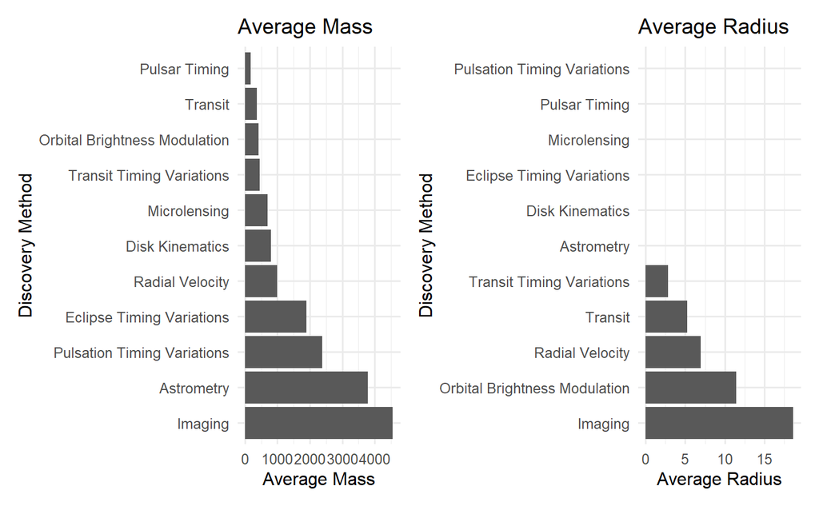

```r
library(patchwork)
plot_mass + plot_radius
```

Combining two plots into one

## TASK 3

### This must be extracted from the references in the pl_refname column where the lead author’s name is specified in the target parameter (e.g.: target=ref>Cale et al. 2021)

```r
df <- df %>%
  mutate(explorer = str_match(df$pl_refname, "target=ref>(.*?)\\set")[, 2])
```

Finding all of the explorers’ (real explorers) names

```r
explorers <- df %>%
  group_by(explorer) %>%
  summarize(count = n()) %>%
  arrange(desc(count)) %>%
  top_n(10, wt = count)
```

Classic group by

```r
kable(explorers, format = "markdown", col.names = c("Discoverer", "Number of Planets Discovered"))
```

| Discoverer | Number of Planets Discovered |
| --- | --- |
| NA | 17830 |
| Morton | 2259 |
| Berger | 2113 |
| Gajdoš | 1973 |
| Holczer | 1905 |
| Rowe | 715 |
| Kokori | 628 |
| Valizadegan | 370 |
| Stassun | 323 |
| Bonomo | 319 |

And printing the table as usual

## TASK 3B

### Create a biplot describing the average size and mass of the planets (in multiples of Earth’s value) in multi-planetary systems as a function of the order of the planets (calculated by distance from the parent star). To determine the order, use the fact that the naming convention indicates the order of the planets by the letter of the Latin alphabet at the end of the name, with the letter “b” (e.g., GJ 367 b) indicating the first planet in the order, “c” the second, etc.

```r
df <- df %>%
  mutate(order = str_sub(pl_name,-1))
```

Finding the order of the planets (last letter)

```r
multi_planet_systems <- df %>%
  group_by(order) %>%
  summarize(average_mass = mean(pl_bmasse, na.rm = TRUE),
            average_radius = mean(pl_rade, na.rm = TRUE))
```

### Calculate the average size and mass of the planets by order

```r
multi_planet_systems <- multi_planet_systems%>%
  filter(!(str_detect(order, "\\d")))
```

Getting rid of the cases where instead of letter we have digits

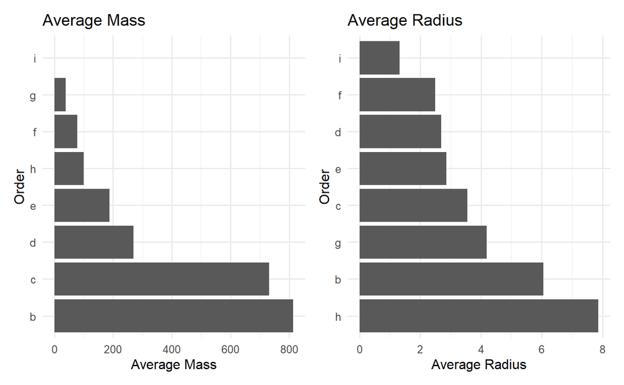

```r
plot_mass2 <- ggplot(multi_planet_systems, aes(x = reorder(order, -average_mass), y = average_mass)) +
  geom_bar(stat = "identity") +
  coord_flip() +
  labs(title = "Average Mass",
       x = "Order",
       y = "Average Mass") +
  theme_minimal()
# Create the plot for average radius
plot_radius2 <- ggplot(multi_planet_systems, aes(x = reorder(order, -average_radius), y = average_radius)) +
  geom_bar(stat = "identity") +
  coord_flip() +
  labs(title = "Average Radius",
       x = "Order",
       y = "Average Radius") +
  theme_minimal()

# Combine the two plots into one canvas side by side
plot_mass2 + plot_radius2
```